# Part II - (What are the Factors That Affect Loan Outcome)

## by (Sussan Omeruah)

## Investigation Overview

> My goal at the beginning of this project was to determine factors that affect Loan outcome, that factors that contribute to a loan being completed, chargedoff/defaulted or delinquent.

> Some of the factors I found that affects loan outcome are Loan Amount, Borrower rate, Loan duration (Term) prosper rating and Income range

> The loan original Amount is multimodal with loan amount of about 5000 having the most peak. The chart suggests that there are relatively more loans with lower amounts and fewer loans with higher amounts

> 2011 has the highest number of completed loans when Loan status is compared over time

> Prosper ratings of 4 (same as C- rating) and above have the largest Loan amounts but lowest borrower rates

## Dataset Overview

> Prosper is a lending platform in the U.S. that offers a variety of resources people can use to try and improve their financial health, regardless of their financial situation. Users can consolidate debt, improve their home, or finance healthcare costs with personal loans among many other purposes. Investors who may be looking for new opportunities to diversify their portfolio can invest in personal loans.

> This data set contains 113,937 loans with 81 variables on each loan, with duration between november 2005 to march 2014, including loan amount, borrower rate (or interest rate), current loan status, borrower income, and many others. See this data dictionary to understand the dataset's variables.

## (Visualization 1)

> A quick look into the distribution of The loan original Amount revealed that Loan amount is multimodal with loan amount of about 5000 having the most peak. The chart suggests that there are relatively more loans with lower amounts and fewer loans with higher amounts

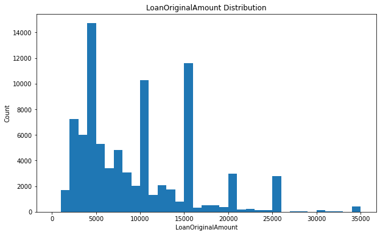

## (Visualization 2)

> When we look at how Loan outcomes have changed over the years, we see that 2011 and 2012 have the highest number of completed loans. However, 2012 also has the highest defaulted loans

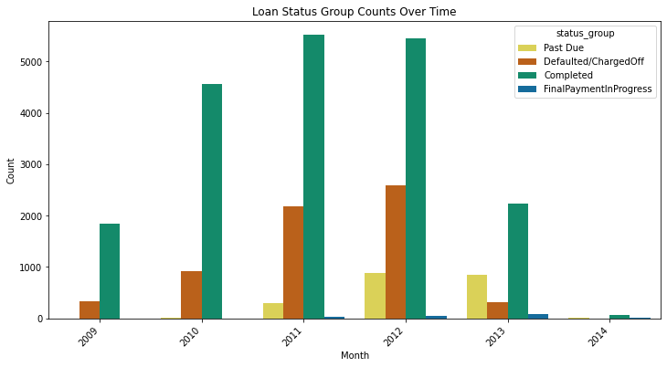

## (Visualization 3)

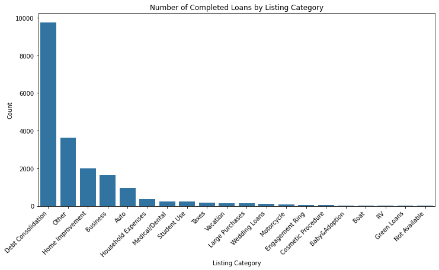

### Visualization 4

Prosper ratings of 4 (same as C- rating) and above have the largest Loan amounts but lowest borrower rates. It appears that Borrowers with high prosper rating get the best loan deals

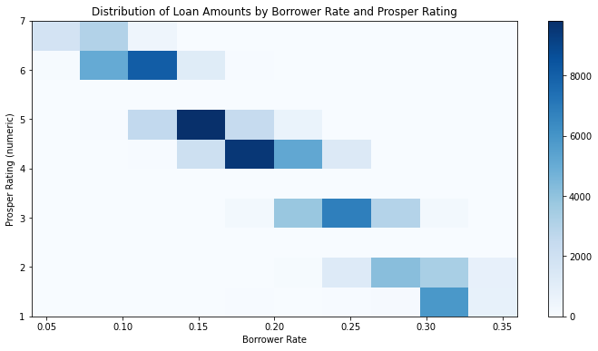

### Visualization 5

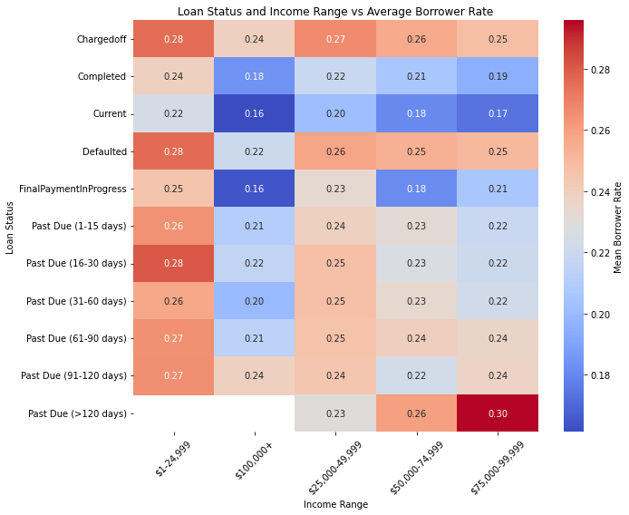

### Visualization 6

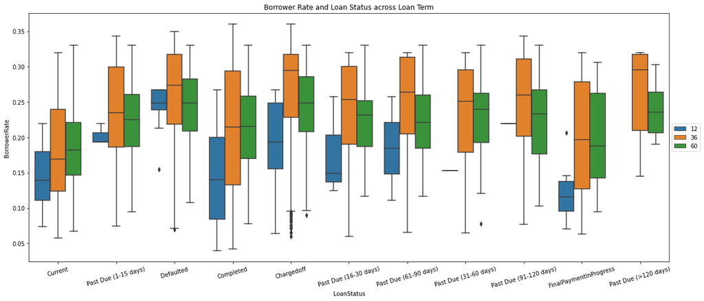